# Doubtful

## Wordcloud

Create a wordcloud from the new spooky_wrd table using the updated stop words.

```r
# Words is a list of words, and freqs their frequencies
words <- count(group_by(spooky_wrd_new, word))$word
freqs <- count(group_by(spooky_wrd_new, word))$n
head(sort(freqs, decreasing = TRUE))
```

```
[1] 3369 1339 1316 1241 1160  788
```

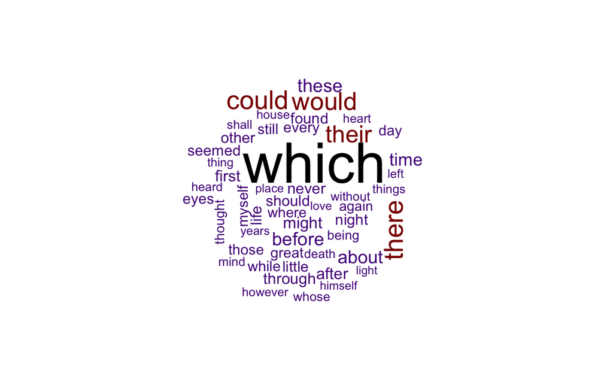

```r
wordcloud(words, freqs, max.words = 50, color = c("purple4", "red4", "black"))
```

Many words which seem to be associated with a sense of doubt such as could, would, should. Some of the other biggest words in the cloud are also a stop word in the original set, such as “which,” “there,” and “their.” Because of their high frequency and relative lack of meaning, “which,” “there,” and “their” will be added to the stop_words_short set and the word cloud will be remade.

```r
new1 <- "which"
new2 <- "there"
new3 <- "their"
stop_words_short<- rbind(stop_words_short, new1)
stop_words_short<- rbind(stop_words_short, new2)
stop_words_short<- rbind(stop_words_short, new3)
tail(stop_words_short, 4)
```

| word |
| --- |
| your |
| which |
| there |
| their |

```r
spooky_wrd_new <- anti_join(spooky_wrd, stop_words_short, by = "word")
# Words is a list of words, and freqs their frequencies
words <- count(group_by(spooky_wrd_new, word))$word
freqs <- count(group_by(spooky_wrd_new, word))$n
head(sort(freqs, decreasing = TRUE))
```

```
[1] 1316 1241  788  786  769  729
```

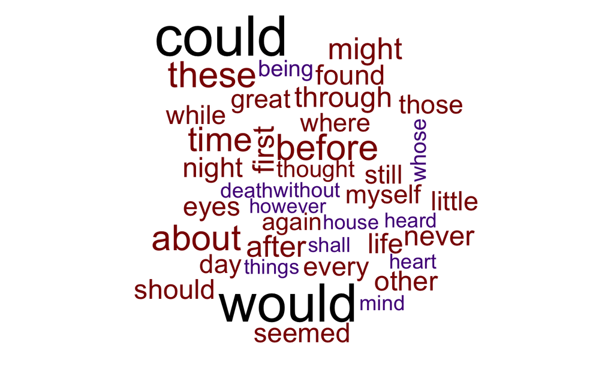

```r
wordcloud(words, freqs, max.words = 40, color = c("purple4", "red4", "black"))
```